# ICU_tests

## Contexte et hypothèses

On veut répondre aux hypothèses suivantes : l’ICU nocturne est plus marqué que l’ICU diurne à Rio sur notre jeu de données ; l’ICU est plus marqué en saison humide qu’en saison sèche.

On veut comparer l’amplitude du cycle jour/nuit (ou saison humide/sèche) en ville à l’amplitude du cycle jour/nuit en zone rurale.

Le test calcule de combien de °C l’écart urbain-rural (= ICU) est plus grand la nuit que le jour, en saison humide qu’en saison sèche.

On fait un masque binaire à partir du raster LCZ (package LCZ4R, Wudapt) où 1 = urbain et 0 = rural.

Pour chaque pixel urbain, l’ICU est défini comme l’écart entre sa température (Ta) et la température rurale moyenne de la même période (ex : Ta_urbain_nuit − Ta_rural_moyenne_nuit).

Cette différence est calculée séparément pour le jour et pour la nuit, puis les deux valeurs sont comparées pixel par pixel (test de Wilcoxon apparié) pour savoir si l’ICU est significativement plus fort la nuit ou en saison humide.

On visualise des cartes de la différence de l’ICU nocturne et diurne | ICU en saison humide et sèche. Les cartes montrent la vitesse à laquelle les pixels urbains se refroidissent par rapport à la campagne.

## Chargement des packages

```r
library(terra)
library(dplyr)
```

```r
library(ggplot2)
```

## Charger les données

```r
output_dir <- "C:/Users/Spagnoli/Desktop/R/rasters_ta_predite"

# Rasters médians déjà produits (script RF_prediction_spatiale)
Ta_seche_nuit  <- rast(file.path(output_dir, "mediane_Ta_nuit_saison_seche.tif"))
Ta_humide_nuit <- rast(file.path(output_dir, "mediane_Ta_nuit_saison_humide.tif"))
Ta_seche_jour  <- rast(file.path(output_dir, "mediane_Ta_jour_saison_seche.tif"))
Ta_humide_jour <- rast(file.path(output_dir, "mediane_Ta_jour_saison_humide.tif"))

# Charger le raster LCZ (script LCZ) et créer le masque urbain en regroupant les catégories urbaines
lcz_raster <- rast("C:/Users/Spagnoli/Desktop/R/predicteurs/LCZ_30m.tif")
masque_urbain <- ifel(lcz_raster == 1 | lcz_raster == 2 | lcz_raster == 3 | lcz_raster == 6 | lcz_raster == 8, 1, 0)
```

## Rééchantillonner le masque urbain pour qu’il corresponde aux rasters Ta

Utiliser le premier raster Ta comme référence pour l’étendue et la résolution.

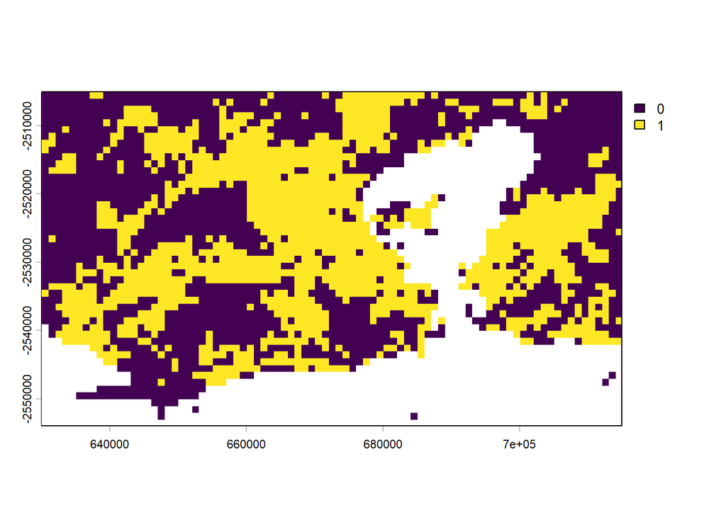

```r
zone_urbain <- resample(masque_urbain, Ta_seche_nuit, method = "near")
plot(zone_urbain)
```

## Empiler les 4 rasters Ta et extraire les pixels urbains alignés

On empile les 4 rasters dans un seul objet SpatRaster multi-couches. L’intérêt : chaque pixel géographique aura une seule ligne dans le data frame final, avec ses 4 valeurs (une par condition) dans les bonnes colonnes. Cela garantit que la comparaison nuit/jour ou sec/humide se fait PIXEL PAR PIXEL, ce qui est indispensable pour le test apparié.

```r
stack_Ta <- c(Ta_seche_nuit, Ta_humide_nuit, Ta_seche_jour, Ta_humide_jour)
names(stack_Ta) <- c("seche_nuit", "humide_nuit", "seche_jour", "humide_jour")

# On masque les zones rurales (zone_urbain == 0 devient NA) pour ne garder
# que les pixels urbains, sur les 4 couches en même temps
stack_urbain <- mask(stack_Ta, zone_urbain, maskvalues = c(0, NA))

# On fait pareil pour les pixels ruraux (on masque les zones urbaines cette fois)
stack_rural <- mask(stack_Ta, zone_urbain, maskvalues = c(1, NA))

# as.data.frame(..., na.rm = TRUE) transforme le raster multi-couches en tableau :
# chaque ligne = un pixel valide, chaque colonne = une condition (nuit|jour|seche|humide)
# na.rm = TRUE supprime les pixels où au moins une des 4 couches est NA,
# ce qui garantit que les 4 colonnes restent alignées ligne par ligne
df_urbain <- as.data.frame(stack_urbain, na.rm = TRUE)
df_rural  <- as.data.frame(stack_rural,  na.rm = TRUE)
```

## Calculer l’ICU pixel par pixel (urbain - moyenne rurale)

Moyenne rurale de référence pour chaque condition (un seul chiffre par condition, calculé sur tous les pixels ruraux valides de cette condition).

```r
Ta_rural_seche_nuit  <- mean(df_rural$seche_nuit)
Ta_rural_humide_nuit <- mean(df_rural$humide_nuit)
Ta_rural_seche_jour  <- mean(df_rural$seche_jour)
Ta_rural_humide_jour <- mean(df_rural$humide_jour)

# ICU par pixel urbain = température du pixel - moyenne rurale de la même condition
# Comme df_urbain a une ligne par pixel et que les 4 colonnes sont alignées,
# on obtient ici un vecteur d'ICU où la position x correspond toujours au même pixel
icu_seche_nuit  <- df_urbain$seche_nuit  - Ta_rural_seche_nuit
icu_humide_nuit <- df_urbain$humide_nuit - Ta_rural_humide_nuit
icu_seche_jour  <- df_urbain$seche_jour  - Ta_rural_seche_jour
icu_humide_jour <- df_urbain$humide_jour - Ta_rural_humide_jour
```

## Construire les vecteurs nuit|jour|sec|humide

Ici on ne concatène plus deux vecteurs indépendants comme avant. On combine les ICU par pixel pour chaque comparaison, en gardant l’appariement (même pixel, conditions différentes).

```r
# NUIT vs JOUR, toutes saisons confondues : on empile les deux
# saisons dans un seul vecteur nuit et un seul vecteur jour, en respectant
# le même ordre de pixels dans les deux (ici : d'abord saison sèche, puis humide)
icu_nuit <- c(icu_seche_nuit, icu_humide_nuit)
icu_jour <- c(icu_seche_jour, icu_humide_jour)
# -> icu_nuit x et icu_jour x correspondent au même pixel à la même saison

# SAISON HUMIDE vs SECHE, jour et nuit confondus : même chose
icu_seche  <- c(icu_seche_jour, icu_seche_nuit)
icu_humide <- c(icu_humide_jour, icu_humide_nuit)
# -> icu_seche x et icu_humide x correspondent au même pixel et au même moment (jour ou nuit)
```

## Vérification de la normalité des différences (justifie le choix de Wilcoxon)

Le test t apparié suppose que les différences suivent une loi normale. On vérifie cette hypothèse avant de choisir entre t-test et Wilcoxon.

```r
diff_nuit_jour   <- icu_nuit - icu_jour
diff_humide_seche <- icu_humide - icu_seche

# Shapiro-Wilk est limité à 5000 obs max -> on teste sur un échantillon aléatoire
set.seed(123)  # pour reproductibilité
n_sample <- 5000

echantillon_nj <- sample(diff_nuit_jour, min(n_sample, length(diff_nuit_jour)))
echantillon_hs <- sample(diff_humide_seche, min(n_sample, length(diff_humide_seche)))

cat("\n--- Test de normalité (Shapiro-Wilk) sur échantillon ---\n")
```

```
##
## --- Test de normalité (Shapiro-Wilk) sur échantillon ---
```

```r
cat("Différences Nuit - Jour :\n")
```

```
## Différences Nuit - Jour :
```

```r
print(shapiro.test(echantillon_nj))
```

```
##
##  Shapiro-Wilk normality test
##
## data:  echantillon_nj
## W = 0.98609, p-value = 1.1e-15
```

```r
cat("\nDifférences Humide - Sèche :\n")
```

```
##
## Différences Humide - Sèche :
```

```r
print(shapiro.test(echantillon_hs))
```

```
##
##  Shapiro-Wilk normality test
##
## data:  echantillon_hs
## W = 0.97568, p-value < 2.2e-16
```

Inspection visuelle (plus fiable ici vu le grand nombre de pixels, Shapiro-Wilk étant très sensible à n élevé -> quasi toujours significatif).

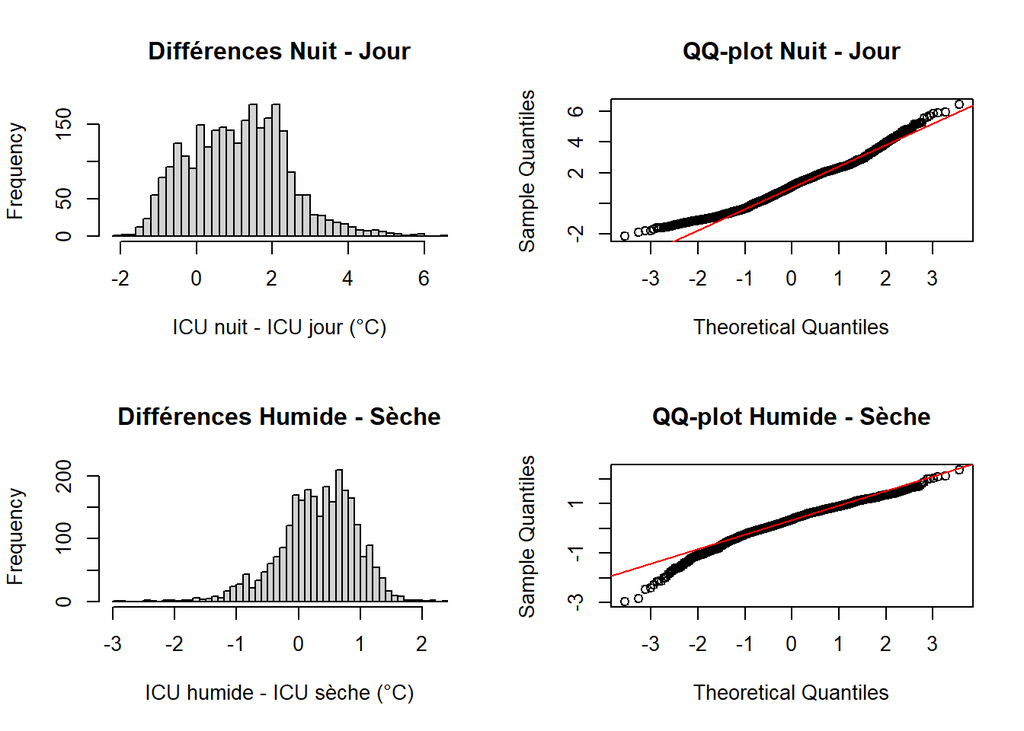

```r
par(mfrow = c(2, 2))

hist(diff_nuit_jour, breaks = 50, main = "Différences Nuit - Jour", xlab = "ICU nuit - ICU jour (°C)")
qqnorm(diff_nuit_jour, main = "QQ-plot Nuit - Jour")
qqline(diff_nuit_jour, col = "red")

hist(diff_humide_seche, breaks = 50, main = "Différences Humide - Sèche", xlab = "ICU humide - ICU sèche (°C)")
qqnorm(diff_humide_seche, main = "QQ-plot Humide - Sèche")
qqline(diff_humide_seche, col = "red")
```

```r
par(mfrow = c(1, 1))  # reset layout
```

## Tests de Wilcoxon appariés

### Test H5 : l’ICU est plus marqué la nuit que le jour

```r
cat("\n--- Test H5 : ICU plus marqué la nuit que le jour ---\n")
```

```
##
## --- Test H5 : ICU plus marqué la nuit que le jour ---
```

```r
test_nuit_vs_jour <- wilcox.test(icu_nuit, icu_jour,
                                 alternative = "greater",
                                 paired = TRUE)   # <- appariement pixel à pixel
print(test_nuit_vs_jour)
```

```
##
##  Wilcoxon signed rank test with continuity correction
##
## data:  icu_nuit and icu_jour
## V = 3286874, p-value < 2.2e-16
## alternative hypothesis: true location shift is greater than 0
```

```r
cat("Différence médiane (Nuit - Jour) :",
    median(icu_nuit - icu_jour), "°C\n")  # médiane des différences
```

```
## Différence médiane (Nuit - Jour) : 1.125193 °C
```

### Test H6 : l’ICU est plus marqué en saison humide qu’en saison sèche

```r
cat("\n--- Test H6 : ICU plus marqué en saison humide qu'en saison sèche ---\n")
```

```
##
## --- Test H6 : ICU plus marqué en saison humide qu'en saison sèche ---
```

```r
test_humide_vs_seche <- wilcox.test(icu_humide, icu_seche,
                                    alternative = "greater",
                                    paired = TRUE)  # <- appariement pixel à pixel
print(test_humide_vs_seche)
```

```
##
##  Wilcoxon signed rank test with continuity correction
##
## data:  icu_humide and icu_seche
## V = 2873692, p-value < 2.2e-16
## alternative hypothesis: true location shift is greater than 0
```

```r
cat("Différence médiane (Humide - Sèche) :",
    median(icu_humide - icu_seche), "°C\n")
```

```
## Différence médiane (Humide - Sèche) : 0.3632163 °C
```

## Cartes de la différence d’ICU (nuit-jour et humide-sec)

Reconstruire l’ICU sous forme de raster (et non plus de vecteur) pour chacune des 4 conditions. On utilise les mêmes moyennes rurales que celles calculées à l’étape précédente pour rester cohérent avec les tests.

```r
icu_raster_seche_nuit  <- Ta_seche_nuit  - Ta_rural_seche_nuit
icu_raster_humide_nuit <- Ta_humide_nuit - Ta_rural_humide_nuit
icu_raster_seche_jour  <- Ta_seche_jour  - Ta_rural_seche_jour
icu_raster_humide_jour <- Ta_humide_jour - Ta_rural_humide_jour

# On ne garde que les pixels urbains : l'ICU n'a de sens que là
# (les pixels ruraux valent 0 par construction, ça n'apporte rien de les garder)
icu_raster_seche_nuit  <- mask(icu_raster_seche_nuit,  zone_urbain, maskvalues = c(0, NA))
icu_raster_humide_nuit <- mask(icu_raster_humide_nuit, zone_urbain, maskvalues = c(0, NA))
icu_raster_seche_jour  <- mask(icu_raster_seche_jour,  zone_urbain, maskvalues = c(0, NA))
icu_raster_humide_jour <- mask(icu_raster_humide_jour, zone_urbain, maskvalues = c(0, NA))

# Carte H5 : ICU nocturne - ICU diurne (saisons moyennées)
icu_nuit_raster <- mean(icu_raster_seche_nuit, icu_raster_humide_nuit)  # moyenne sec+humide, la nuit
icu_jour_raster <- mean(icu_raster_seche_jour, icu_raster_humide_jour)  # moyenne sec+humide, le jour

diff_icu_nuit_jour <- icu_nuit_raster - icu_jour_raster

# Carte H6 : ICU saison humide - ICU saison sèche (jour+nuit moyennés)
icu_humide_raster <- mean(icu_raster_humide_jour, icu_raster_humide_nuit)  # moyenne jour+nuit, saison humide
icu_seche_raster  <- mean(icu_raster_seche_jour,  icu_raster_seche_nuit)   # moyenne jour+nuit, saison sèche

diff_icu_humide_seche <- icu_humide_raster - icu_seche_raster
```

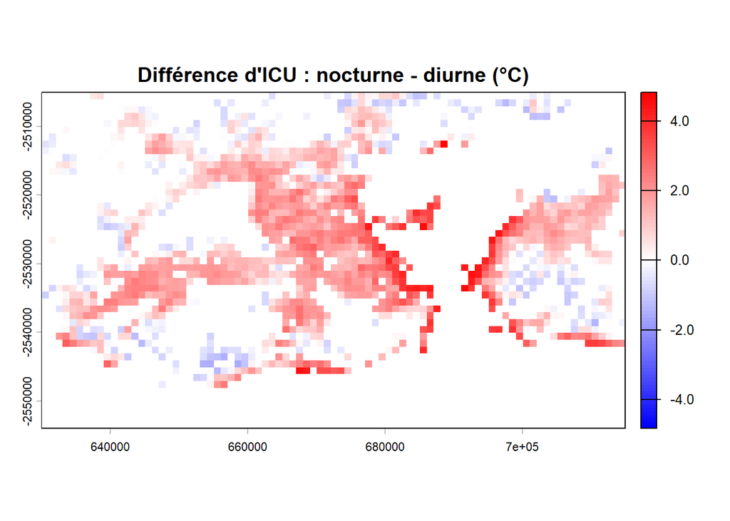

```r
# Calculer une échelle commune aux deux cartes pour comparaison honnête
max_abs_nuit_jour   <- max(abs(minmax(diff_icu_nuit_jour)))
max_abs_humide_seche <- max(abs(minmax(diff_icu_humide_seche)))
max_abs_commun <- max(max_abs_nuit_jour, max_abs_humide_seche)

plot(diff_icu_nuit_jour,
     main = "Différence d'ICU : nocturne - diurne (°C)",
     col = colorRampPalette(c("blue", "white", "red"))(100),
     range = c(-max_abs_commun, max_abs_commun))
```

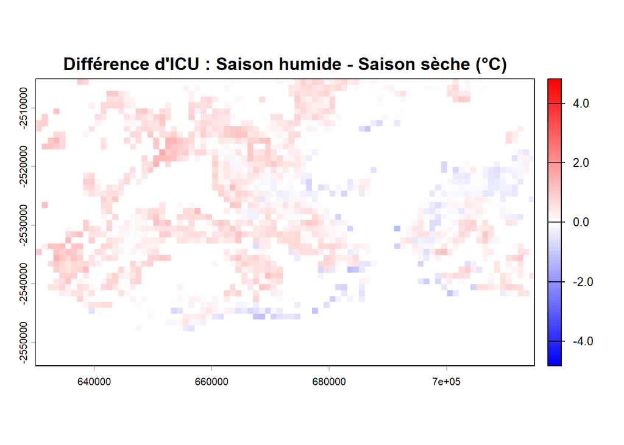

```r
# Carte montre la vitesse à laquelle les pixels urbains se refroidissent par rapport à la campagne
# En rouge: pixel urbain refroidit moins vite la nuit que la campagne -> l'écart de Ta urbain/rural est + grand la nuit que le jour -> ICU nocturne ++ à cet endroit
# En bleu: pixel urbain refroidit presque aussi vite ou plus vite la nuit que la campagne-> écart urbain/rural ne s'accentue pas la nuit il reste stable ou se réduit
# Ecart de Ta urb/rural + marqué la nuit (pixels rouges) que le jour (pixels bleus)

plot(diff_icu_humide_seche,
     main = "Différence d'ICU : Saison humide - Saison sèche (°C)",
     col = colorRampPalette(c("blue", "white", "red"))(100),
     range = c(-max_abs_commun, max_abs_commun))
```

```r
# En rouge: pixel urbain refroidit moins vite en saison humide que la campagne -> l'écart de Ta urbain/rural est + grand en saison humide qu'en saison sèche -> ICU saison hum ++ à cet endroit
# En bleu: pixel urbain refroidit presque aussi vite ou plus vite en saison humide que la campagne-> écart urbain/rural ne s'accentue pas en saison humide il reste stable ou se réduit
# Ecart de Ta urb/rural + marqué en saison hum (pixels rouges) qu'en saison sèche (pixels bleus)
```

## Boxplot comparatif des amplitudes de différence d’ICU

Comparer la distribution des différences nuit-jour et humide-sec sur les pixels urbains.

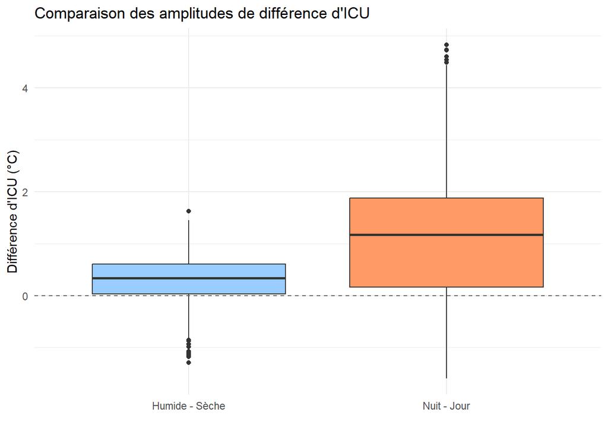

```r
diff_nj_vals <- values(diff_icu_nuit_jour, na.rm = TRUE)
diff_hs_vals <- values(diff_icu_humide_seche, na.rm = TRUE)

df_boxplot <- data.frame(
  difference = c(diff_nj_vals, diff_hs_vals),
  comparaison = c(rep("Nuit - Jour", length(diff_nj_vals)),
                  rep("Humide - Sèche", length(diff_hs_vals)))
)

ggplot(df_boxplot, aes(x = comparaison, y = difference, fill = comparaison)) +
  geom_boxplot() +
  geom_hline(yintercept = 0, linetype = "dashed", color = "grey40") +
  scale_fill_manual(values = c("Nuit - Jour" = "#FF9966",
                               "Humide - Sèche" = "#99CCFF")) +
  labs(title = "Comparaison des amplitudes de différence d'ICU",
       x = "", y = "Différence d'ICU (°C)") +
  theme_minimal() +
  theme(legend.position = "none")
```

## Carte de l’ICU nocturne

`icu_nuit_raster` déjà calculé plus haut (ICU nocturne, moyenne saisons).

Pour un lissage sur environ 2 pixels d’écart-type (soit ~2000m si résolution = 1000m).

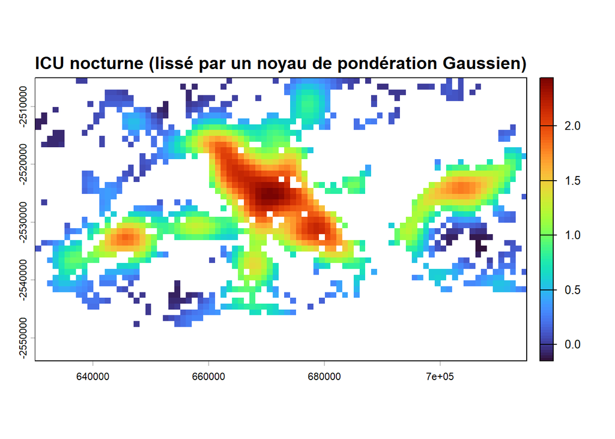

```r
poids_gauss <- focalMat(icu_nuit_raster, d = 2000, type = "Gauss")
# focalMat(..., type = "Gauss") crée un noyau de pondération gaussien (plus de poids au centre,
# moins sur les bords), ce qui donne un rendu plus doux qu'une simple moyenne uniforme.
# Augmenter d pour plus de lissage

icu_nuit_lisse <- focal(icu_nuit_raster, w = poids_gauss, fun = "sum", na.policy = "omit", na.rm = TRUE)

library(viridisLite)

plot(icu_nuit_lisse,
     main = "ICU nocturne (lissé par un noyau de pondération Gaussien)",
     col = turbo(100))
```

## Vérifier l’autocorrélation spatiale avec un corrélogramme

Une des conditions d’application principale du test de Wilcoxon apparié est de tester sur des paires indépendantes. Or jusqu’ici, les données avec lesquelles on travaille sont dépendantes spatialement (la Ta d’un pixel influence celle de son voisin). On cherche alors à savoir où s’arrête l’autocorrélation spatiale, d’abord en faisant un corrélogramme, puis en sous-échantillonnant nos rasters pour s’affranchir de cette autocorrélation (en ne prenant qu’1 pixel tous les x mètres).

```r
library(ncf)

# On travaille sur le raster de différence (ex: diff_icu_nuit_jour)
# Extraire les coordonnées et les valeurs des pixels urbains valides
coords_vals <- as.data.frame(diff_icu_nuit_jour, xy = TRUE, na.rm = TRUE)
names(coords_vals) <- c("x", "y", "diff")

# Corrélogramme spatial (peut être lent sur un grand raster -> sous-échantillonner
# pour CETTE étape d'estimation, ex: 2000 points aléatoires suffisent)
set.seed(123)
sample_idx <- sample(nrow(coords_vals), min(2000, nrow(coords_vals)))
sub <- coords_vals[sample_idx, ]

correlog_result <- correlog(sub$x, sub$y, sub$diff,
                            increment = 1000,  #à ajuster selon résolution, en metres
                            resamp = 100)
```

```
## 10  of  100 20  of  100 30  of  100 40  of  100 50  of  100 60  of  100 70  of  100 80  of  100 90  of  100 100  of  100
```

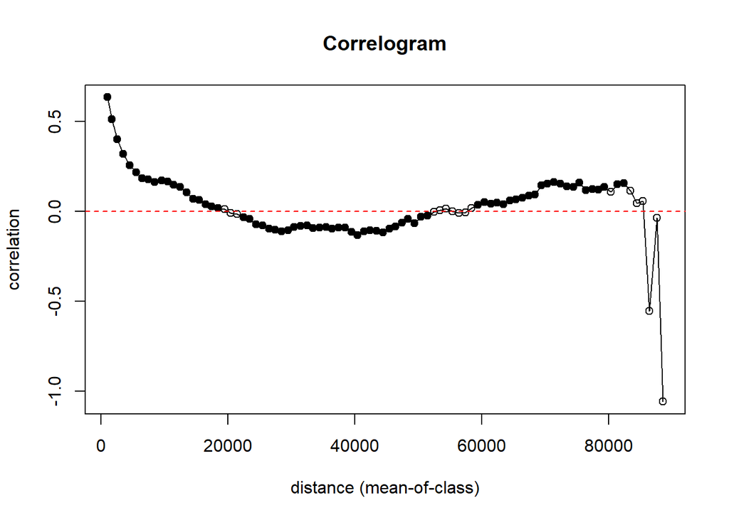

```r
plot(correlog_result)
abline(h = 0, col = "red", lty = 2)
```

```r
# on regarde où le premier endroit où la courbe croise 0 = distance où l'autocorrélation spatiale s'arrête
```